# Simulation Results: Distribution of AMKAT P-value Estimator Under PhiMr (Incomplete)

## Discrete Features

We initialize the simulation setting for the case where the components of $\boldsymbol{X}$ represent discrete additive-encoded (0-1-2 quantitative minor allele count) single-nucleotide polymorphism (SNP) data:

```r
x_type <- 'snp'
p <- 567
source(file.path(dir_src, "initialize_adaptive_within.R"))
```

### Data Set #6

This data set was generated using the following scenario parameters:

```r
n <- 50 # sample size
signal_density <- 'sparse' # 28 signal variables
error_correlation_strength <- 0.5 # mixed directions
```

We load the test and permutation statistics generated on this data set:

```r
pv_files <- pvaluePlotFiles()
load(pv_files$stats)
load(pv_files$pvalues)
```

#### Distribution of Test and Permutation Statistics

We first plot the distributions of the test statistics and permutation statistics with and without the PhiMr filter:

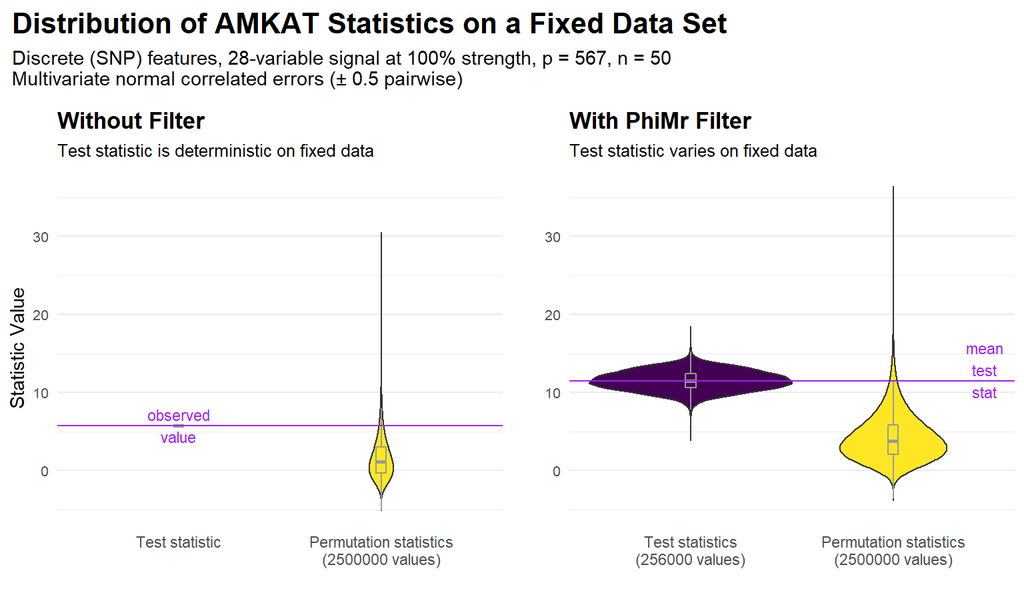

```r
makeStatDistrPlots(
  test_stats, perm_stats, perm_stats_no_filter, test_stat_no_filter)
```

#### Distribution of P-values

After partitioning the test and permutation statistics into batches and using them to estimate $P$-values, we plot the distributions of the resulting $P$-values.

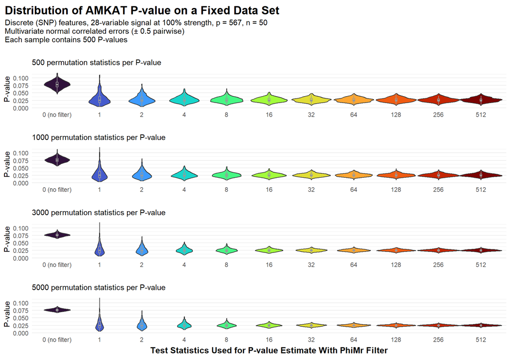

```r
makeViolinQPlots(pvalues, title_settings = title_violinQ(num_replicates))
```

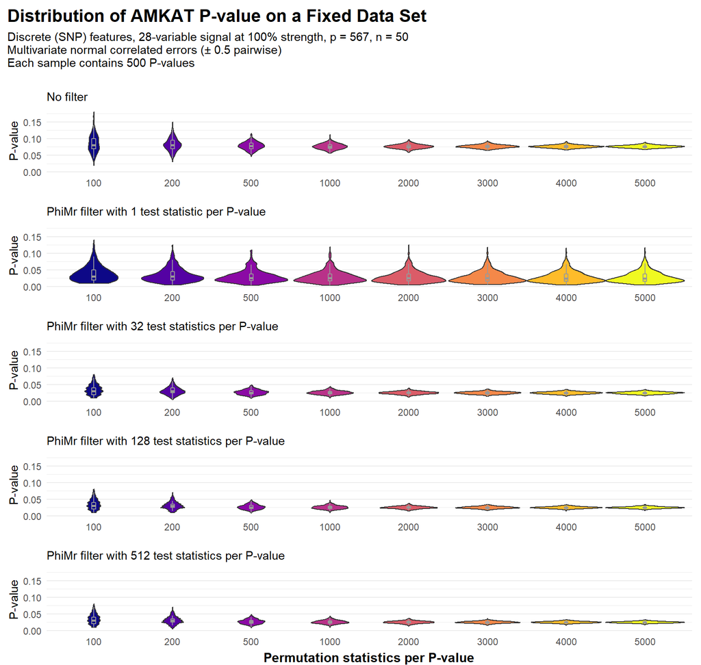

```r
makeViolinBPlots(pvalues, title_settings = title_violinB(num_replicates))
```

#### P-value Mean and Standard Deviation

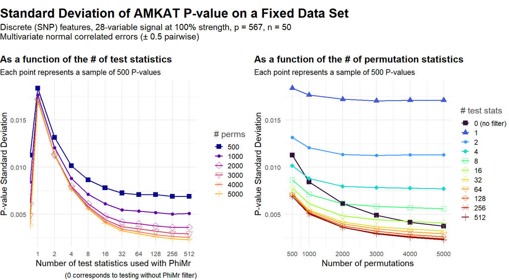

```r
makePVLinePlots(pvalues, num_replicates)
```

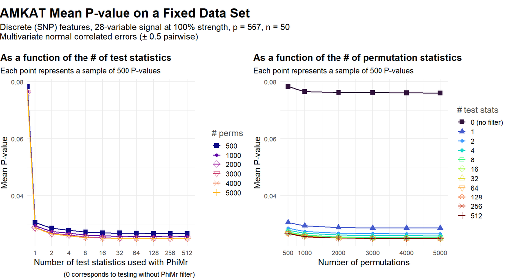

```r
makePVLinePlots(pvalues, num_replicates, summary_stat = mean,
                title_settings =
                  title_pvline(
                    joint_title = "AMKAT Mean P-value on a Fixed Data Set"))
```

#### Distribution of Variable Retention Rates by PhiMr

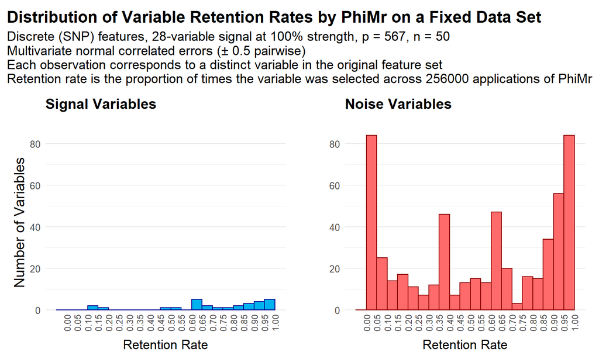

```r
makePhimrHistograms(feature_select_rates,
                    getSignalIndices(x_type, signal_density))
```

### Data Set #7

This data set was generated using the following scenario parameters:

```r
n <- 50 # sample size
signal_density <- 'dense' # 123 signal variables
error_correlation_strength <- 0 # independent errors
```

We load the test and permutation statistics generated on this data set:

```r
pv_files <- pvaluePlotFiles()
load(pv_files$stats)
load(pv_files$pvalues)
```

#### Distribution of Test and Permutation Statistics

We first plot the distributions of the test statistics and permutation statistics with and without the PhiMr filter:

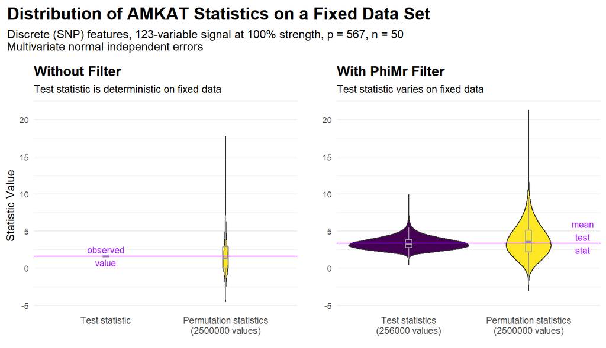

```r
makeStatDistrPlots(
  test_stats, perm_stats, perm_stats_no_filter, test_stat_no_filter)
```

#### Distribution of P-values

After partitioning the test and permutation statistics into batches and using them to estimate $P$-values, we plot the distributions of the resulting $P$-values.

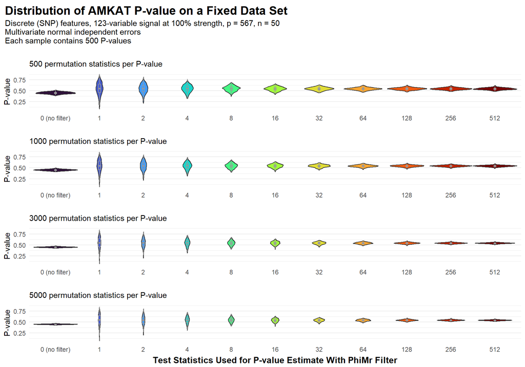

```r
makeViolinQPlots(pvalues, title_settings = title_violinQ(num_replicates))
```

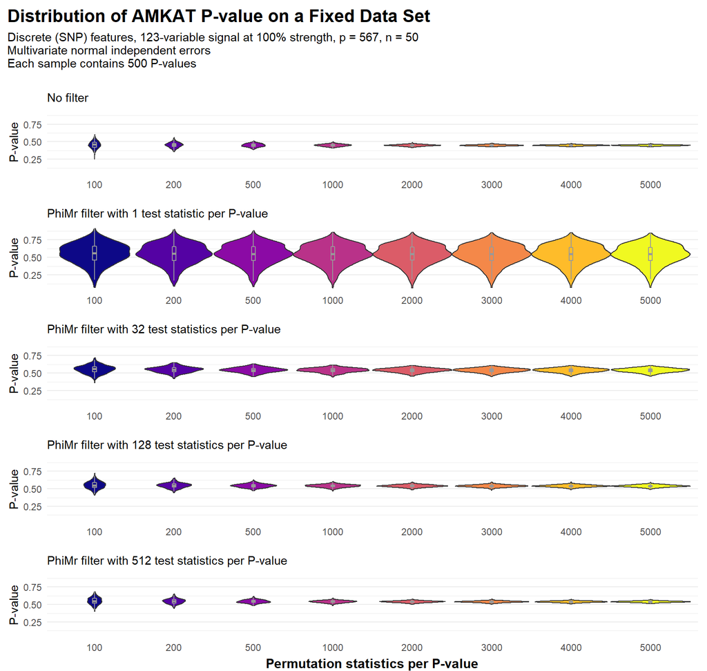

```r
makeViolinBPlots(pvalues, title_settings = title_violinB(num_replicates))
```

#### P-value Mean and Standard Deviation

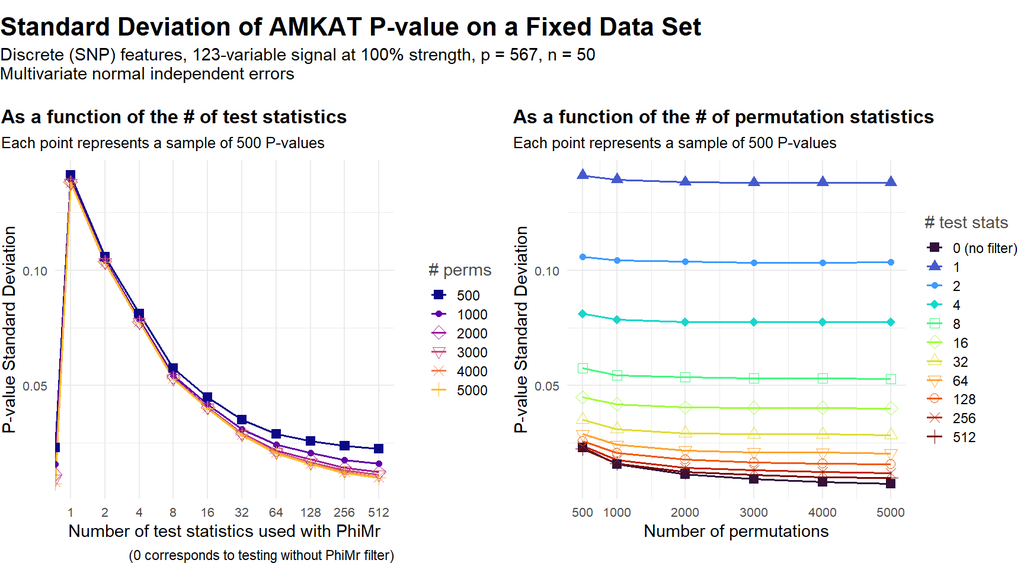

```r
makePVLinePlots(pvalues, num_replicates)
```

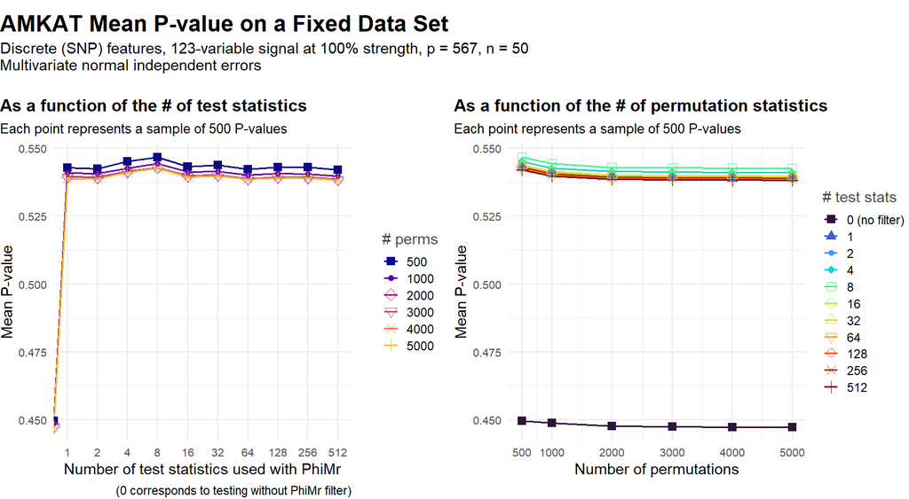

```r
makePVLinePlots(pvalues, num_replicates, summary_stat = mean,
                title_settings =
                  title_pvline(
                    joint_title = "AMKAT Mean P-value on a Fixed Data Set"))
```

#### Distribution of Variable Retention Rates by PhiMr

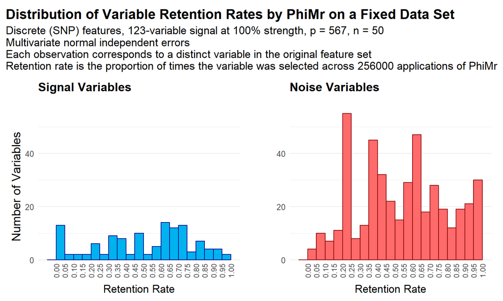

```r
makePhimrHistograms(feature_select_rates,
                    getSignalIndices(x_type, signal_density))
```